# R Notebook

- Question 1

** Importing necessary library

```r
library(caret)
```

First, the data set is imported into the notebook.

```r
data <- read_csv("Advertising.csv")
attach(data)
```

Then we have a quick inspect in the data set.

```r
str(data)
```

```
tibble [200 × 5] (S3: spec_tbl_df/tbl_df/tbl/data.frame)
 $ X1       : num [1:200] 1 2 3 4 5 6 7 8 9 10 ...
 $ TV       : num [1:200] 230.1 44.5 17.2 151.5 180.8 ...
 $ radio    : num [1:200] 37.8 39.3 45.9 41.3 10.8 48.9 32.8 19.6 2.1 2.6 ...
 $ newspaper: num [1:200] 69.2 45.1 69.3 58.5 58.4 75 23.5 11.6 1 21.2 ...
 $ Sales    : num [1:200] 22.1 10.4 9.3 18.5 12.9 7.2 11.8 13.2 4.8 10.6 ...
 - attr(*, "spec")=
  .. cols(
  ..   X1 = col_double(),
  ..   TV = col_double(),
  ..   radio = col_double(),
  ..   newspaper = col_double(),
  ..   Sales = col_double()
  .. )
```

```r
summary(data)
```

```
       X1               TV             radio          newspaper          Sales
 Min.   :  1.00   Min.   :  0.70   Min.   : 0.000   Min.   :  0.30   Min.   : 1.60
 1st Qu.: 50.75   1st Qu.: 74.38   1st Qu.: 9.975   1st Qu.: 12.75   1st Qu.:10.38
 Median :100.50   Median :149.75   Median :22.900   Median : 25.75   Median :12.90
 Mean   :100.50   Mean   :147.04   Mean   :23.264   Mean   : 30.55   Mean   :14.02
 3rd Qu.:150.25   3rd Qu.:218.82   3rd Qu.:36.525   3rd Qu.: 45.10   3rd Qu.:17.40
 Max.   :200.00   Max.   :296.40   Max.   :49.600   Max.   :114.00   Max.   :27.00
```

Plot a histogram of `Sales`, `TV`, `radio` and `newspaper` individually

```r
par(mfrow = c(2,2))
hist(TV,breaks = seq(0,300,30))
hist(radio)
```

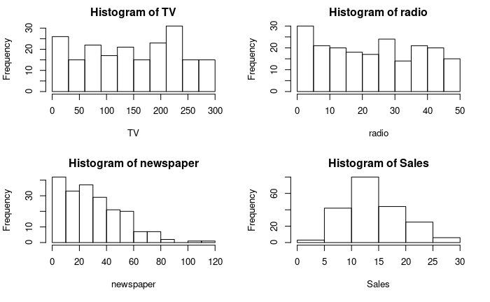

```r
hist(newspaper)
hist(Sales)
```

```r
?hist
```

The spread of data in `TV` seems to be even. However, in `radio` and `newspaper`, there are higher frequency of lower value investment with `newspaper` having a more obvious trend. From the histogram, we observed that `Sales` are roughly normally distributed with slight skewed to the right.

Next, we plot scatter plot of `Sales` vs `TV`, `radio`, and `newspaper` individually.

```r
par(mfrow = c(1,3))
plot(TV, Sales, main = "Sales vs TV")
plot(radio, Sales, main = "Sales vs radio")
```

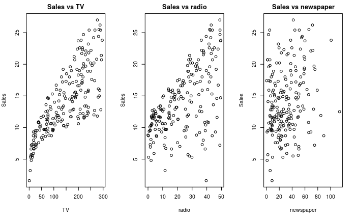

```r
plot(newspaper, Sales, main = "Sales vs newspaper")
```

Now we randomly shuffle the data.

```r
set.seed(100) # To produce reproducible result

data <- data %>%
  select(Sales,TV,radio,newspaper) %>%
  mutate(rand = runif(dim(data)[1]),) %>%
  arrange(rand)

head(data)
```

| Sales | TV | radio | newspaper | rand |
| --- | --- | --- | --- | --- |
| 9.3 | 17.2 | 45.9 | 69.3 | 0.01154550 |
| 19.2 | 137.9 | 46.4 | 59.0 | 0.01618339 |
| 13.4 | 232.1 | 8.6 | 8.7 | 0.01902087 |
| 5.7 | 8.4 | 27.2 | 2.1 | 0.01959930 |
| 5.3 | 5.4 | 29.9 | 9.4 | 0.02672845 |
| 14.7 | 74.7 | 49.4 | 45.7 | 0.02847401 |

From the scatter plot, we observe that `Sales` is a concave function of `TV`. Hence, we will try to fit the data with concave function such as $\sqrt{TV}$. The relationship between `Sales` and `Radio` is roughly linear observing from the graph while there seems to not have any correlation between `Sales` and `Newspaper`. We will compute a correlation matrix to find out.

```r
cor(select(data,-rand))
```

```
              Sales         TV      radio  newspaper
Sales     1.0000000 0.78222442 0.57622257 0.22829903
TV        0.7822244 1.00000000 0.05480866 0.05664787
radio     0.5762226 0.05480866 1.00000000 0.35410375
newspaper 0.2282990 0.05664787 0.35410375 1.00000000
```

From the correlation matrix, we can see that `Sales` is highly correlated to `TV` and `Radio` with $r = 0.782$ and $r = 0.576$ respectively, while `Sales` is weakly correlated with `Newspaper` with $r = 0.228$. Do note that the predictors `Radio` and `Newspaper` are correlated to each other with $r = 0.354$. Hence, we expect only one of either will make a good predictor.

Now we will use repeated K-fold cross validation (K = 10) and fit with a linear regression $\hat{Sales}=\beta_0+\beta_1\cdot\sqrt{TV}+\beta_2\cdot radio+\beta_3\cdot newspaper$

```r
# First we set training control to repeated K-fold cross validation
# with K = 10, and repeats = 3
train.control <- trainControl(method = "repeatedcv",
                              number = 10, repeats = 3)

# Then we train the linear model
model1 <- train(Sales ~ I(sqrt(TV)) + radio + newspaper, data = data, method = "lm",
               trControl = train.control)

# Summary of the result
summary(model1)
```

```
Call:
lm(formula = .outcome ~ ., data = dat)

Residuals:
    Min      1Q  Median      3Q     Max
-5.3147 -0.8536  0.0294  0.8485  3.4205

Coefficients:
                Estimate Std. Error t value Pr(>|t|)
(Intercept)   -1.6092798  0.3362200  -4.786 3.34e-06 ***
`I(sqrt(TV))`  0.9749476  0.0240384  40.558  < 2e-16 ***
radio          0.1947679  0.0071549  27.222  < 2e-16 ***
newspaper     -0.0005253  0.0048803  -0.108    0.914
---
Signif. codes:  0 ‘***’ 0.001 ‘**’ 0.01 ‘*’ 0.05 ‘.’ 0.1 ‘ ’ 1

Residual standard error: 1.401 on 196 degrees of freedom
Multiple R-squared:  0.929, Adjusted R-squared:  0.9279
F-statistic: 854.3 on 3 and 196 DF,  p-value: < 2.2e-16
```

```r
print(model1)
```

```
Linear Regression

200 samples
  3 predictor

No pre-processing
Resampling: Cross-Validated (10 fold, repeated 3 times)
Summary of sample sizes: 180, 180, 179, 180, 180, 181, ...
Resampling results:

  RMSE      Rsquared   MAE
  1.410167  0.9325496  1.100246

Tuning parameter 'intercept' was held constant at a value of TRUE
```

From the statistics we have, $R^2_{adj}=0.9279$ and $F=854.3$ ($p<2.2\times10^{-16}$), this is considered a good model.

However, when we look closely into the t-values of the predictors, we noticed that both `sqrt(TV)` and `radio` are significant with $p<2\times10^{-16}$ while `newspaper` is not significant with $p = 0.914$.

The coefficients of the predictors told us that for every 1 additional unit of `sqrt(TV)` invested, 0.975 unit of `Sales` will be generated; for every 1 additional unit of `radio` invested, 0.195 unit of `Sales` will be generated; for every 1 additional unit of `newspaper` invested, -0.0005 unit of `Sales` will be generated, which is a loss.

Now, we will use Variance Inflation Factor(VIF) to check for multicollinearity.

```r
vif(model1$finalModel)
```

```
`sqrt(TV)`      radio  newspaper
  1.002183   1.143614   1.144868
```

From the VIF generated, the $VIF_{\sqrt{TV}}\approx1$, $VIF_{radio}=1.14$ and $VIF_{newspaper}=1.14$ shows that there is some collinearity between the predictors `radio` and `newspaper`.

Next we try to train the model without the predictor `newspaper`.

```r
# Then we train the linear model
model2 <- train(Sales ~ I(sqrt(TV)) + radio, data = data, method = "lm",
               trControl = train.control)

# Summary of the result
summary(model2)
```

```
Call:
lm(formula = .outcome ~ ., data = dat)

Residuals:
    Min      1Q  Median      3Q     Max
-5.2997 -0.8514  0.0371  0.8599  3.4128

Coefficients:
               Estimate Std. Error t value Pr(>|t|)
(Intercept)   -1.617931   0.325651  -4.968 1.46e-06 ***
`I(sqrt(TV))`  0.974854   0.023962  40.683  < 2e-16 ***
radio          0.194496   0.006677  29.131  < 2e-16 ***
---
Signif. codes:  0 ‘***’ 0.001 ‘**’ 0.01 ‘*’ 0.05 ‘.’ 0.1 ‘ ’ 1

Residual standard error: 1.398 on 197 degrees of freedom
Multiple R-squared:  0.929, Adjusted R-squared:  0.9282
F-statistic:  1288 on 2 and 197 DF,  p-value: < 2.2e-16
```

```r
print(model2)
```

```
Linear Regression

200 samples
  2 predictor

No pre-processing
Resampling: Cross-Validated (10 fold, repeated 3 times)
Summary of sample sizes: 180, 180, 180, 180, 181, 179, ...
Resampling results:

  RMSE      Rsquared   MAE
  1.389224  0.9347209  1.090008

Tuning parameter 'intercept' was held constant at a value of TRUE
```

We can see the new model without the predictor `newspaper` has a higher $F=1288$ and $R^2_{adj}=0.9282$, which indicates that this is a slightly better model compared to the model with `newspaper`. We will do an ANOVA test to confirm.

```r
anova(model1$finalModel, model2$finalModel)
```

```
Analysis of Variance Table

Model 1: .outcome ~ `I(sqrt(TV))` + radio + newspaper
Model 2: .outcome ~ `I(sqrt(TV))` + radio
  Res.Df    RSS Df Sum of Sq      F Pr(>F)
1    196 384.86
2    197 384.88 -1 -0.022748 0.0116 0.9144
```

However, the ANOVA test has a $p=0.9144$, which means that we cannot reject the null hypothesis that `model1` and `model2` fits the data equally well. There is no sufficient evidence that the model without the `newspaper` feature is significantly better.

Of course, we will check again the VIF of the predictors for any multicollinearity.

```r
vif(model2$finalModel)
```

[output not shown]

Next up, we will plot the residual graphs to inspect how are the residuals distributed.

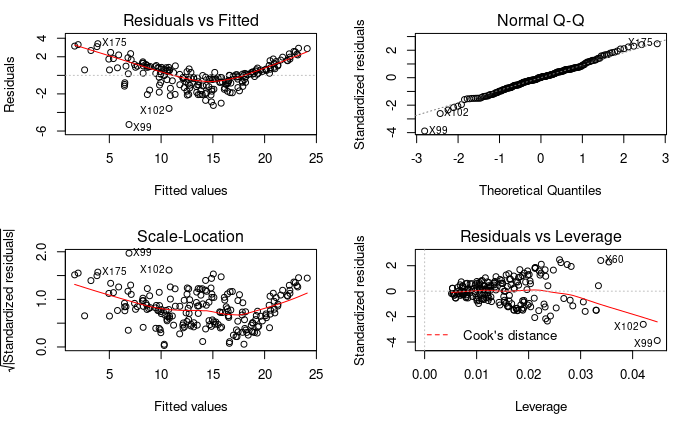

```r
par(mfrow = c(2,2))
plot(model2$finalModel)
```

We can see that the residuals are not randomly distributed across the 0 abline. This indicates that there are some bias going on with current model. We now try out the 3D scatter plot of the raw and predicted data to inspect.

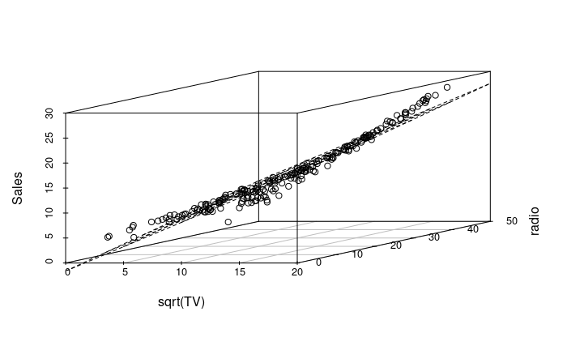

```r
s3d <- scatterplot3d(x = sqrt(TV), y = radio, z = Sales, angle = 30)

# adding in the prediction plane
s3d$plane3d(model2$finalModel)
```

We can see that at the extreme value(pure input) of either `radio` or `sqrt(TV)`, the model underestimate the data, while when there is a mixed input from both predictors, the model overestimate the data. It clearly shows that there are some synergy or interaction between the 2 predictors term. Hence, we will fit again a model with interaction term between the 2 predictors.

$\hat{Sales}=\beta_0+\beta_1\cdot\sqrt{TV}+\beta_2\cdot radio+\beta_3\cdot\sqrt{TV}\times radio$

```r
# Model with interaction term
model3 <- train(Sales ~ I(sqrt(TV)) * radio, data = data, method = "lm",
               trControl = train.control)

# Summary of the result
summary(model3)
```

```
Call:
lm(formula = .outcome ~ ., data = dat)

Residuals:
    Min      1Q  Median      3Q     Max
-2.0562 -0.2757 -0.0121  0.2758  1.2421

Coefficients:
                      Estimate Std. Error t value Pr(>|t|)
(Intercept)          4.4444112  0.1793714  24.778  < 2e-16 ***
`I(sqrt(TV))`        0.4383960  0.0150223  29.183  < 2e-16 ***
radio               -0.0500957  0.0062645  -7.997 1.09e-13 ***
`I(sqrt(TV)):radio`  0.0215106  0.0005179  41.538  < 2e-16 ***
---
Signif. codes:  0 ‘***’ 0.001 ‘**’ 0.01 ‘*’ 0.05 ‘.’ 0.1 ‘ ’ 1

Residual standard error: 0.4476 on 196 degrees of freedom
Multiple R-squared:  0.9928,    Adjusted R-squared:  0.9926
F-statistic:  8949 on 3 and 196 DF,  p-value: < 2.2e-16
```

```r
print(model3)
```

```
Linear Regression

200 samples
  2 predictor

No pre-processing
Resampling: Cross-Validated (10 fold, repeated 3 times)
Summary of sample sizes: 179, 180, 181, 180, 180, 179, ...
Resampling results:

  RMSE       Rsquared   MAE
  0.4497255  0.9932823  0.3435817

Tuning parameter 'intercept' was held constant at a value of TRUE
```

We can see that the new model has a $R^2_{adj}=0.993$ and $F=8949$ which is way higher than the previous 2 models. We will do ANOVA test to compare this model with `model2`.

```r
# Comparing with model2
anova(model2$finalModel, model3$finalModel)
```

```
Analysis of Variance Table

Model 1: .outcome ~ `I(sqrt(TV))` + radio
Model 2: .outcome ~ `I(sqrt(TV))` + radio + `I(sqrt(TV)):radio`
  Res.Df    RSS Df Sum of Sq      F    Pr(>F)
1    197 384.88
2    196  39.26  1    345.62 1725.4 < 2.2e-16 ***
---
Signif. codes:  0 ‘***’ 0.001 ‘**’ 0.01 ‘*’ 0.05 ‘.’ 0.1 ‘ ’ 1
```

We can see that the $p<2.2\times 10^{-16}$ of the ANOVA test rejects the null hypothesis that `model2` and `model3` fits equally well. Hence, there is evidence that the model with interaction term fits significantly better than then the model without the interaction term.

We can also plot the residual plot to see how the residuals are distributed.

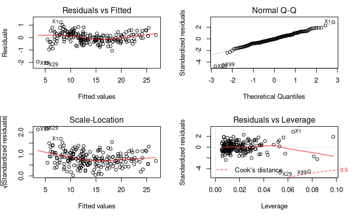

```r
par(mfrow = c(2,2))
plot(model3$finalModel)
```

Now we can see that the residuals are roughly randomly distributed across the 0 abline.